# Getting started with ctsem

Source: [`vignettes/ctsem.qmd`](https://github.com/cdriveraus/ctsem/blob/master/vignettes/ctsem.qmd)

This article works through one analysis from start to end: the model, the data, specifying and fitting a model, reading the results, adding a covariate and checking the model. It assumes ctsem and its Julia engine are installed, as the README describes.

```r
library(ctsem)
library(ggplot2)
```

## The model

A ctsem model describes one or more latent processes that change over time, and the variables measured at the times they were observed. Within each subject the processes $\boldsymbol\eta(t)$ follow

$$\mathrm{d}\boldsymbol\eta(t) = \big(A\,\boldsymbol\eta(t) + \mathbf b + M\boldsymbol\chi(t)\big)\,\mathrm{d}t + G\,\mathrm{d}\mathbf W(t)$$

and the measurements are

$$\mathbf y(t) = \Lambda\,\boldsymbol\eta(t) + \boldsymbol\tau + \boldsymbol\epsilon(t),
\qquad \boldsymbol\epsilon(t) \sim N(\mathbf 0, \Theta)$$

Each symbol is a matrix of `ctModel()`:

| Matrix | Symbol | Holds | Default |
| --- | --- | --- | --- |
| `DRIFT` | $A$ | auto effects (diagonal) and cross effects between processes | free |
| `CINT` | $\mathbf b$ | continuous time intercepts | zero |
| `DIFFUSION` | $G$ | size and correlation of the random shocks to the processes | free |
| `TDPREDEFFECT` | $M$ | effects of time dependent predictors $\boldsymbol\chi$ | free |
| `T0MEANS` |  | the processes’ values at each subject’s first observation | free, varying over subjects |
| `T0VAR` |  | their variance at the first observation | covered by the random `T0MEANS` |
| `LAMBDA` | $\Lambda$ | loadings of the measured variables on the processes | must be given |
| `MANIFESTMEANS` | $\boldsymbol\tau$ | intercepts of the measured variables | free, varying over subjects |
| `MANIFESTVAR` | $\Theta$ | measurement error | free standard deviations |

The drift matrix describes how the processes change. With a negative auto effect, a process on its own returns towards its equilibrium after a shock. A cross effect is the effect of one process on the rate of change of another. Whether the processes together return to equilibrium depends on the whole drift matrix, which `vignette('dynamics')` explains. The diffusion describes the random shocks that move the processes between observations, and so carry forward in time. Measurement error affects only the observation it belongs to. A time dependent predictor, such as an intervention, shifts the processes at the times it is observed, and the dynamics carry the shift forward.

Any parameter can differ between subjects, as a random effect, and depend on subject level covariates (time independent predictors). By default the initial states and the intercepts of the measured variables differ between subjects, which allows for stable differences between people.

With `type = 'dt'` the same matrices describe a discrete time model, in which `DRIFT` holds the autoregressive and cross-lagged coefficients from one occasion to the next.

## Data

ctsem takes data in long format: one row per subject and occasion, with a column for the subject id, one for the time, and one for each measured variable and predictor.

- Times are numbers, in whatever unit suits the processes, such as hours, days or years. They need not be equally spaced and can differ between subjects. The estimated effects are per unit of time, so the unit decides their scale. A unit over which the processes change noticeably, but do not settle completely, usually works best.
- A missing value is `NA`. A row can have some variables observed and others missing.
- A time independent predictor must have the same value on every row of a subject.
- A time dependent predictor is an input at the time of its row, and zero means no input.

The data for this article are simulated, so that the estimates can be compared with the values that generated them. One hundred people rated their stress and mood about once a day, at irregular times, for a month or so, and some ratings are missing. In the generating model stress lowers mood but mood does not affect stress, each person has their own typical stress and mood, and older people tend to be more stressed. `age` is standardised.

```r
set.seed(1)
gen <- ctModel(type = 'ct', silent = TRUE,
  manifestNames = c('stress', 'mood'), latentNames = c('stress', 'mood'),
  LAMBDA = diag(2), TIpredNames = 'age',
  DRIFT = matrix(c(-0.5, 0, -0.25, -0.3), 2, 2, byrow = TRUE),
  DIFFUSION = matrix(c(0.8, 0, 0, 0.6), 2, 2, byrow = TRUE),
  CINT = matrix(0, 2, 1), T0MEANS = matrix(0, 2, 1), T0VAR = diag(1, 2),
  MANIFESTMEANS = matrix(c('mm_stress|param|TRUE|0.5|age=0.3',
    'mm_mood|param|TRUE|0.5'), 2, 1),
  MANIFESTVAR = diag(0.4, 2))
dat <- ctGenerate(gen, n = 100, Tpoints = 30, dtmean = 1, logdtsd = 0.5,
  backend = 'julia', values = c(mm_stress = 3, mm_mood = 5))
truelevels <- attr(dat, 'subjectpars')
dat <- data.frame(dat)
dat$time <- round(dat$time, 2)
dat$stress[sample(nrow(dat), 200)] <- NA
dat$mood[sample(nrow(dat), 200)] <- NA
head(dat)
```

```
#>   id time   stress     mood       age
#> 1  1 0.00 2.700413 4.601892 0.7391149
#> 2  1 0.73 3.065700       NA 0.7391149
#> 3  1 1.83 2.319692 4.910601 0.7391149
#> 4  1 2.49       NA 6.159872 0.7391149
#> 5  1 4.71 4.396647 3.978655 0.7391149
#> 6  1 5.89 3.555298 5.576969 0.7391149
```

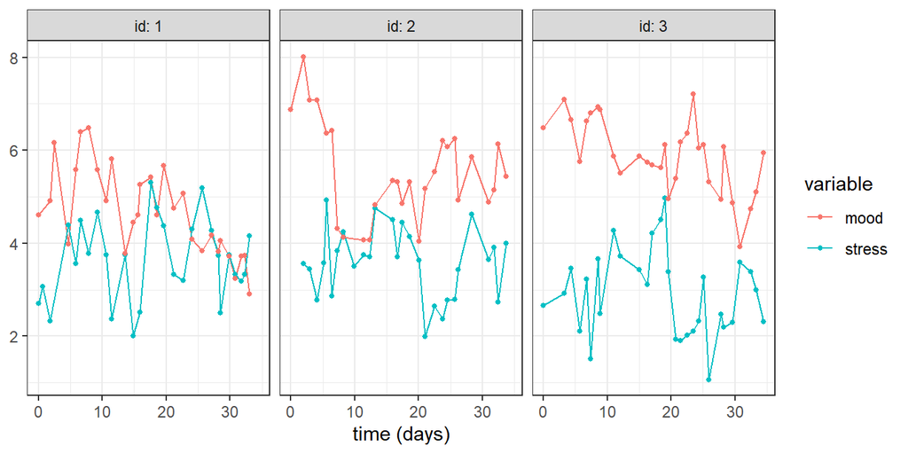

```r
long <- rbind(
  data.frame(dat[dat$id <= 3, c('id', 'time')], variable = 'stress',
    value = dat$stress[dat$id <= 3]),
  data.frame(dat[dat$id <= 3, c('id', 'time')], variable = 'mood',
    value = dat$mood[dat$id <= 3]))
ggplot(long[!is.na(long$value), ], aes(time, value, colour = variable)) +
  geom_line() + geom_point(size = 1) + facet_wrap(~id, labeller = label_both) +
  theme_bw() + labs(x = 'time (days)', y = NULL)
```

Data in wide format, with one row per subject, can be converted. `ctWideToLong()` gives one row per occasion, and `ctDeintervalise()` turns the time intervals of wide data into times:

```r
data(ctExample1)
colnames(ctExample1)
```

```
#>  [1] "LeisureTime_T0" "Happiness_T0"   "LeisureTime_T1" "Happiness_T1"
#>  [5] "LeisureTime_T2" "Happiness_T2"   "LeisureTime_T3" "Happiness_T3"
#>  [9] "LeisureTime_T4" "Happiness_T4"   "LeisureTime_T5" "Happiness_T5"
#> [13] "dT1"            "dT2"            "dT3"            "dT4"
#> [17] "dT5"
```

```r
widelong <- ctWideToLong(ctExample1, Tpoints = 6, n.manifest = 2,
  manifestNames = c('LeisureTime', 'Happiness'))
widelong <- data.frame(ctDeintervalise(widelong))
head(widelong)
```

```
#>   id time LeisureTime Happiness
#> 1  1    0    3.810624  11.15498
#> 2  1    1    3.501790  10.23646
#> 3  1    3    3.860780  12.26379
#> 4  1    4    5.210285  11.78601
#> 5  1    9    1.021253  10.05061
#> 6  1   18    4.623846  12.09391
```

## Specifying the model

Each process is measured by one variable, with a loading of 1, so `LAMBDA` is an identity matrix. `ctModel()` takes the names of the time and id columns from its `time` and `id` arguments, which default to `'time'` and `'id'`.

```r
model <- ctModel(LAMBDA = diag(2),
  manifestNames = c('stress', 'mood'), latentNames = c('stress', 'mood'))
model
```

```
#> ctsem model (continuous time)
#>   2 latent (stress, mood), 2 manifest (stress, mood)
#>
#> 13 free parameters
#>
#> 4 individually varying: T0m_stress, T0m_mood, mm_stress, mm_mood
#>   This is a multilevel model. It estimates a 4 x 4 population covariance
#>   over those parameters -- 4 standard deviations and 6 correlations on top of the 13 above.
#>   Set indvarying = FALSE in a cell (see ?ctPar) for any that should not vary.
#>
#> T0MEANS
#>
#> stress T0m_stress
#> mood     T0m_mood
#>
#> T0VAR
#>                   stress       mood
#> stress      T0var_stress          0
#> mood   T0var_mood_stress T0var_mood
#>
#> DRIFT
#>                   stress              mood
#> stress      drift_stress drift_stress_mood
#> mood   drift_mood_stress        drift_mood
#>
#> DIFFUSION
#>                  stress      mood
#> stress      diff_stress         0
#> mood   diff_mood_stress diff_mood
#>
#> CINT
#>
#> stress 0
#> mood   0
#>
#> LAMBDA
#>        stress mood
#> stress      1    0
#> mood        0    1
#>
#> MANIFESTMEANS
#>
#> stress mm_stress
#> mood     mm_mood
#>
#> MANIFESTVAR
#>            stress     mood
#> stress mvarstress        0
#> mood            0 mvarmood
```

Printing the model shows each matrix, with the name of each free parameter and the value of each fixed one. Everything not given to `ctModel()` takes the defaults in the table above. `ctModelLatex(model)` writes the same model as equations, and opens them as a pdf if LaTeX is installed:

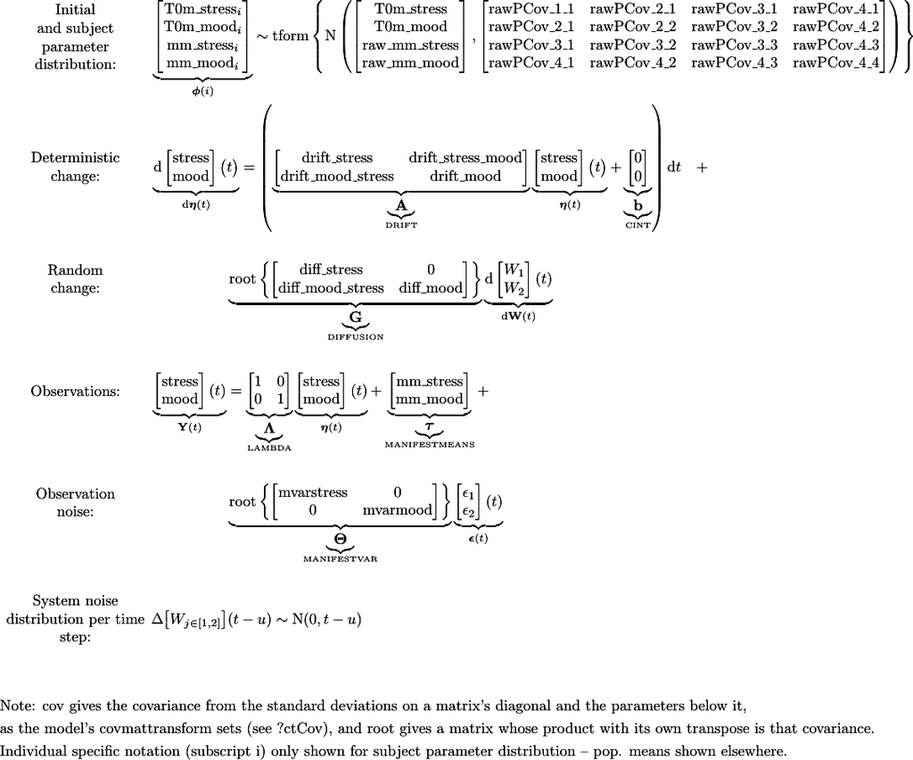

The first line is the distribution of the random effects. Each person’s starting values and measurement intercepts are drawn from a normal distribution, on the raw scale of the parameters, and then transformed. The next two lines are the dynamics, the two after them the measurement, and the last line the distribution of the random shocks over an interval.

To change a matrix, give it to `ctModel()`. A number fixes a cell, and a name estimates it. This drift matrix would fix the effect of mood on stress at zero:

```r
DRIFT = matrix(c('drift_stress',      0,
                 'drift_mood_stress', 'drift_mood'), 2, 2, byrow = TRUE)
```

The same model can be written in lavaan, Mplus or formula syntax, which `vignette('model-syntax')` describes.

## Fitting

```r
fit <- ctFit(dat, model, cores = 2)
```

By default `ctFit()` finds the maximum likelihood estimates, integrating over the latent states and over the differences between people. `cores` sets the number of CPU cores to use. `priors = TRUE` adds weakly informative priors, which helps with small data sets, and `optimize = FALSE` samples the posterior instead of optimising. `vignette('uncertainty')` compares these.

## Reading the results

`summary(fit)` prints every part of the result. The population values of the parameters are in `popmeans`:

```r
s <- summary(fit)
s$popmeans
```

```
#>                     mean    sd   2.5%    50%  97.5%   mode
#> T0m_stress        -0.104 0.108 -0.321 -0.103  0.106 -0.105
#> T0m_mood          -0.042 0.098 -0.227 -0.043  0.169 -0.040
#> drift_stress      -0.540 0.055 -0.654 -0.539 -0.437 -0.538
#> drift_stress_mood  0.034 0.033 -0.027  0.034  0.099  0.032
#> drift_mood_stress -0.235 0.029 -0.295 -0.233 -0.179 -0.235
#> drift_mood        -0.347 0.032 -0.411 -0.346 -0.288 -0.347
#> diff_stress        0.866 0.051  0.769  0.865  0.967  0.863
#> diff_mood_stress  -0.002 0.041 -0.084 -0.004  0.078 -0.002
#> diff_mood          0.642 0.032  0.580  0.642  0.708  0.643
#> mvarstress         0.366 0.036  0.305  0.363  0.443  0.364
#> mvarmood           0.368 0.022  0.327  0.367  0.414  0.366
#> mm_stress          3.062 0.081  2.914  3.061  3.223  3.064
#> mm_mood            5.096 0.063  4.977  5.097  5.225  5.096
```

Each row is a parameter, with its estimate (`mean`), standard error (`sd`) and 95% interval.

- `drift_stress` and `drift_mood` are the auto effects, per day. On its own, stress one unit above its equilibrium changes at a rate of about -0.5 units a day, and after one day about `exp(-0.54)`, or 0.58, of the deviation is left.
- `drift_mood_stress` is the effect of stress on mood: more stress lowers the rate of change of mood. `drift_stress_mood`, the effect of mood on stress, is small and its interval includes zero.
- `diff_stress` and `diff_mood` are the standard deviations of the random shocks. `diff_mood_stress` is a parameter for their correlation, and is not itself a correlation. The correlation is in `s$parmatrices` and `ctSummaryMatrices(fit)$estimate$DIFFUSIONcor`.
- `mvarstress` and `mvarmood` are the measurement error standard deviations.
- `mm_stress` and `mm_mood` are the average levels of the two variables, and `T0m_stress` and `T0m_mood` where the processes start relative to them.

The drift matrix as a whole decides whether the processes are stable and how fast they change. They are stable when every eigenvalue has a negative real part, and the eigenvalues give the time scale:

```r
est <- ctSummaryMatrices(fit)$estimate
est$DRIFT
```

```
#>            stress        mood
#> stress -0.5380869  0.03192653
#> mood   -0.2346860 -0.34671108
```

```r
eigen(est$DRIFT)$values
```

```
#> [1] -0.4831845 -0.4016134
```

```r
log(2) / abs(eigen(est$DRIFT)$values)    # half-lives, in days
```

```
#> [1] 1.434539 1.725906
```

Both eigenvalues are negative, and a disturbance to the system halves in one and a half to two days.

How much people differ is in `popsd`, the standard deviations of the random effects:

```r
s$popsd
```

```
#>             mean    sd  2.5%   50% 97.5%  mode
#> T0m_stress 0.928 0.088 0.768 0.924 1.098 0.922
#> T0m_mood   0.851 0.085 0.691 0.846 1.029 0.842
#> mm_stress  0.709 0.059 0.598 0.706 0.829 0.707
#> mm_mood    0.514 0.058 0.411 0.513 0.643 0.512
```

People differ in their typical stress by a standard deviation of about 0.7 and in their typical mood by about 0.5.

Since the data are simulated, the dynamic parameters can be set against the values that generated them:

```r
pars <- c('drift_stress', 'drift_stress_mood', 'drift_mood_stress',
  'drift_mood', 'diff_stress', 'diff_mood', 'mvarstress', 'mvarmood')
data.frame(truth = c(-0.5, 0, -0.25, -0.3, 0.8, 0.6, 0.4, 0.4),
  s$popmeans[pars, c('mean', '2.5%', '97.5%')])
```

```
#>                   truth   mean  X2.5. X97.5.
#> drift_stress      -0.50 -0.540 -0.654 -0.437
#> drift_stress_mood  0.00  0.034 -0.027  0.099
#> drift_mood_stress -0.25 -0.235 -0.295 -0.179
#> drift_mood        -0.30 -0.347 -0.411 -0.288
#> diff_stress        0.80  0.866  0.769  0.967
#> diff_mood          0.60  0.642  0.580  0.708
#> mvarstress         0.40  0.366  0.305  0.443
#> mvarmood           0.40  0.368  0.327  0.414
```

Every interval contains the generating value.

### Effects over time

A cross effect in a continuous time model is an effect on a rate of change. The effect of stress on mood over a given time interval, the cross-lagged coefficient a discrete time model would estimate, depends on the interval:

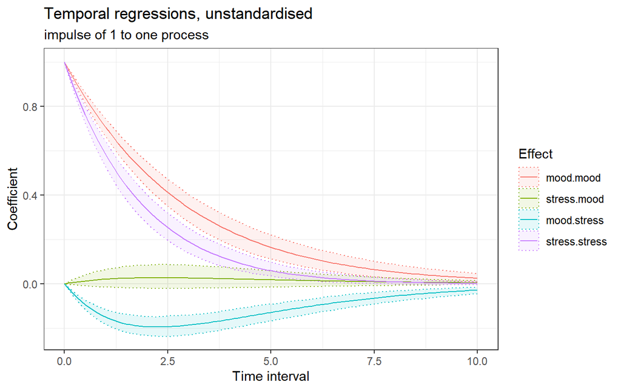

```r
ctDiscretePars(fit, times = seq(0, 10, by = 0.1), plot = TRUE)
```

A unit of stress is followed by lower mood, most strongly two to three days later, when the effect is about -0.2. `summary()` of `ctDiscretePars(fit, times = ...)` gives the peaks and their times, and `vignette('dynamics')` explains these curves.

### Individual trajectories

`ctPredict()` gives the model’s predictions for each person over time. The plot shows the observations, and lines for each person’s expected values given their earlier observations, with 95% intervals. The lines jump at each observation, as it updates the prediction. `kalmanvec = 'ysmooth'` uses all of a person’s observations instead.

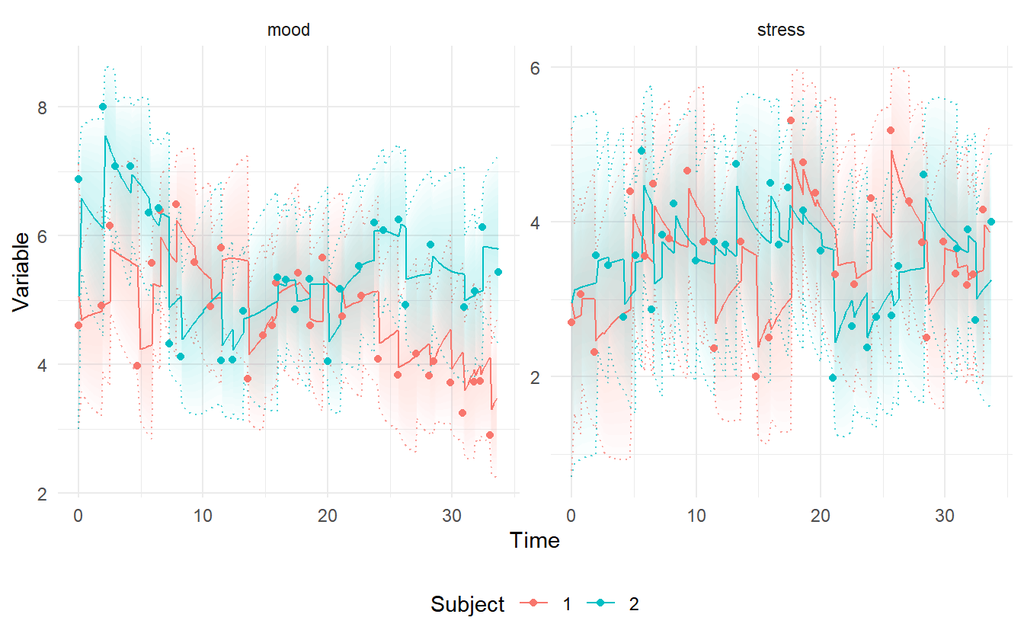

```r
ctPredict(fit, subjects = 1:2, plot = TRUE)
```

`ctSubjectPars()` gives each person’s estimated parameters, here their own typical levels and starting states. They are close to the levels that generated the data:

```r
sp <- ctSubjectPars(fit)
dim(sp)                     # draws x subjects x parameters
```

```
#> [1]   1 100   4
```

```r
cor(sp[1, , 'mm_stress'], truelevels$mm_stress)
```

```
#> [1] 0.9474248
```

## A covariate

Age is in the data but not in the model. `ctScoreTest()` tests, without refitting, whether a covariate would improve the model, and estimates the effect it would have on each parameter:

```r
covariates <- unique(dat[, c('id', 'age')])
ctScoreTest(fit, covariates = covariates, tests = 'covariates')
```

[output not shown]

Age affects the typical stress level, `mm_stress`, by about 0.3 per standard deviation of age, and no other parameter stands out. In the model, a covariate is a time independent predictor (`TIpredNames`), and its effects are given in the `tipreds` field of the parameters it affects. With `tipredDefault = FALSE` it affects only those.

```r
model2 <- ctModel(LAMBDA = diag(2),
  manifestNames = c('stress', 'mood'), latentNames = c('stress', 'mood'),
  TIpredNames = 'age', tipredDefault = FALSE,
  MANIFESTMEANS = c('mm_stress, tipreds=c(age)', 'mm_mood'))
fit2 <- ctFit(dat, model2, cores = 2)
summary(fit2)$tipreds
```

```
#>                    mean    sd  2.5%   50% 97.5%  mode     z
#> tip_age_mm_stress 0.313 0.057 0.204 0.314 0.429 0.316 5.446
```

```r
anova(fit, fit2)
```

```
#> Likelihood-ratio tests, each fit against the one above it
#>
#>      npar   AIC   BIC  logLik  -2LL  Chisq Df Pr(>Chisq)
#> fit    23 13053 13191 -6503.4 13007
#> fit2   24 13028 13172 -6490.0 12980 26.854  1  2.194e-07 ***
#> ---
#> Signif. codes:  0 '***' 0.001 '**' 0.01 '*' 0.05 '.' 0.1 ' ' 1
```

`ctPar()` writes such cell strings, with fields for a cell’s transform, its random effect and its covariate effects.

## Checking the model

`ctScoreTest()` also tests whether parameters the model holds fixed should differ between people, whether the dynamics depend on the level of a process, and whether cells fixed at zero should be free:

```r
ctScoreTest(fit2)
```

```
#> Score tests at the fitted model (laplace route, 100 subjects)
#>
#> Unmodelled heterogeneity (LM: the variance with its covariances, against an
#> equal mixture of chi-square on df - 1 and df; z: the variance alone, one sided;
#> p: the stronger of the two; sd: the one-step estimate, raw scale):
#>          parameter     LM df       z      p p_adj     sd sd_natural
#>       drift_stress 11.400  5 -1.1700 0.0755 0.619     NA         NA
#>  drift_mood_stress  9.220  5 -0.9160 0.1380 0.619     NA         NA
#>         drift_mood  6.330  5 -0.7510 0.4000 0.846     NA         NA
#>   diff_mood_stress  6.070  5  0.0922 0.4160 0.846 0.0256     0.0256
#>        diff_stress  4.440  5 -0.2080 0.6460 0.846     NA         NA
#>           mvarmood  4.070  5 -0.4270 0.7140 0.846     NA         NA
#>         mvarstress  1.370  5 -0.0616 0.7620 0.846     NA         NA
#>          diff_mood  1.830  5 -0.1460 0.7800 0.846     NA         NA
#>  drift_stress_mood  0.743  5 -0.2880 0.8460 0.846     NA         NA
#> Covariances with: T0m_stress, T0m_mood, mm_stress, mm_mood
#>
#> A new dimension of variation: largest eigenvalue 2.32, p = 0.956; direction drift_mood 1, drift_stress -0.55, mvarmood 0.5, drift_mood_stress -0.42, mvarstress -0.36
#>
#> State dependence of the drift:
#>  equation    LM df     p
#>    stress 4.400  3 0.240
#>      mood 0.824  3 0.842
#>       all 5.270  6 0.552
#>
#>           term equation      LM     p p_adj estimate     se
#>  stress*stress   stress 2.36000 0.124 0.746 -0.02910 0.0190
#>      mood*mood   stress 0.66800 0.414 0.959  0.01910 0.0234
#>    stress*mood     mood 0.25600 0.613 0.959  0.01270 0.0251
#>  stress*stress     mood 0.22000 0.639 0.959  0.01080 0.0231
#>    stress*mood   stress 0.01000 0.920 0.975 -0.00348 0.0348
#>      mood*mood     mood 0.00102 0.975 0.975       NA     NA
#>                                                                     reads
#>                                   DRIFT[stress,stress] varies with stress
#>                                       DRIFT[stress,mood] varies with mood
#>      DRIFT[mood,stress] varies with mood, or DRIFT[mood,mood] with stress
#>                                     DRIFT[mood,stress] varies with stress
#>  DRIFT[stress,stress] varies with mood, or DRIFT[stress,mood] with stress
#>                                         DRIFT[mood,mood] varies with mood
#>
```

[output cut: 18 more lines]

```
#>  mm_stress  9.670  9 0.508
#>    mm_mood  0.101  9 1.000
#>        all 19.800 18 0.678
#>
#>                           term      LM      p p_adj estimate     se class
#>  drift_mood_stress ~ mm_stress 4.23000 0.0397 0.715   0.0655 0.0319  <NA>
#>  drift_stress_mood ~ mm_stress 2.65000 0.1030 0.873  -0.0622 0.0382  <NA>
#>        diff_stress ~ mm_stress 1.97000 0.1610 0.873   0.0324 0.0231  <NA>
#>         mvarstress ~ mm_stress 1.69000 0.1940 0.873   0.0319 0.0246  <NA>
#>          diff_mood ~ mm_stress 1.18000 0.2770 0.994   0.0218 0.0200  <NA>
#>         drift_stress ~ mm_mood 0.03040 0.8620 0.994       NA     NA     A
#>     diff_mood_stress ~ mm_mood 0.02430 0.8760 0.994       NA     NA     C
#>    drift_mood_stress ~ mm_mood 0.01520 0.9020 0.994       NA     NA  <NA>
#>          diff_stress ~ mm_mood 0.01220 0.9120 0.994       NA     NA  <NA>
#>             mvarmood ~ mm_mood 0.00798 0.9290 0.994       NA     NA     D
```

Nothing stands out once the tests are adjusted for their number (`p_adj`). `ctFitAdequacy()` tests the model’s one-step-ahead predictions against the data, and `ctModelImprove()` searches for a better model step by step. `vignette('score-tests')` describes all three.

## Where next

- `vignette('dynamics')`: reading drift matrices, stability, time scales and effects over time.
- `vignette('interventions')`: time dependent predictors, with effects that are immediate, lasting or gradual.
- `vignette('model-syntax')`: models in lavaan, Mplus or formula syntax.
- `vignette('measurement-models')`: several indicators, and binary, ordinal, count and censored variables.
- `vignette('laplace-multilevel')`: random effects, and subjects nested in groups.
- `vignette('uncertainty')`: standard errors, sampling and priors.
- `vignette('score-tests')`: checking and improving a model.
- The [website](https://cdriveraus.github.io/ctsem/articles/) has worked examples of a single long time series, growth curves, discrete time models, accelerated designs and the Kalman filter and smoother, and an article on why ctsem models change in continuous time.